# Probability

Sung Won Kang

2016년 11월 12일

### Section 1: 확률

#### 1. 확률의 정의

(뭔가 매우 헷갈리는 말이 많이 쓰여 있으므로 무시)

- 시행(trial)/실험(experiment): 주사위 던지기
  - 결과는 사전에는 모르고 사후에는 확인
  - `… 중 하나가 결과가 된다.’는 정보는 사전에 알려져 있음
- 결과(outcome) : 주사위를 던져서 나온 값
- 표본공간(Sample Space): 주사위 던져서 나올 수 있는 모든 값
  $$\Omega = \{1,2,3,4,5,6\}$$
- 사건(Event): 주사위 눈으로 만들 수 있는 부분집합
  $$A\in \{\phi,\{1\},\{1,2\},\{3,4,5\},\{1,2,3,4,5,6\}\}$$
  - 근원사건($A_i$): 사건 중 원소가 하나인 사건
    $$A_i\in \{\{1\},\{2\},\{3\},\{4\},\{5\},\{6\}\}$$
- 확률(probability): 모든 사건에 할당하는 척도(얼마나 자주 일어날까?)
  - 0과 1 사이
    $$0\le P(A) \le 1$$
  - 표본 공간에 할당하는 확률은 1
    $$P(\Omega)=1$$
  - 겹치지 않는 두 사건이 함께 일어날 사건의 확률 = 각 사건의 확률의 합
    $$P(A\cup B)=P(A)+P(B)\qquad (\forall \{A,B\}\quad A\cap B =\phi)$$
- 확률공간: 확률이 정의된 실험
  - 표본공간, ‘사건의 집합’, 확률

```r
library(prob)

## 표본공간

# 동전던지기
tosscoin(1)
```

```
##   toss1
## 1     H
## 2     T
```

```r
# 주사위 굴리기
rolldie(1)
```

```
##   X1
## 1  1
## 2  2
## 3  3
## 4  4
## 5  5
## 6  6
```

```r
# 1,2,3 중 서로 다른 2개를 고르기
urnsamples(1:3,size=2)
```

```
##   X1 X2
## 1  1  2
## 2  1  3
## 3  2  3
```

```r
# 1,2,3 중 2개를 고르기 (똑같은 것을 골라도 됨)
urnsamples(1:3, size=2, replace=T)
```

```
##   X1 X2
## 1  1  1
## 2  1  2
## 3  1  3
## 4  2  2
## 5  2  3
## 6  3  3
```

```r
# 빨간공 3개, 푸른공 2개 있는 주머니에서 2개 고르기
urnsamples(c(rep("R",3),rep("B",2)),size=2)
```

```
##    X1 X2
## 1   R  R
## 2   R  R
## 3   R  B
## 4   R  B
## 5   R  R
## 6   R  B
## 7   R  B
## 8   R  B
## 9   R  B
## 10  B  B
```

```r
urnsamples(c(paste("R",(1:3),sep=""),paste("B",(1:2),sep="")),size=2)
```

```
##    X1 X2
## 1  R1 R2
## 2  R1 R3
## 3  R1 B1
## 4  R1 B2
## 5  R2 R3
## 6  R2 B1
## 7  R2 B2
## 8  R3 B1
## 9  R3 B2
## 10 B1 B2
```

```r
# 통전 2개 던지는 실험의 확률공간 (정상적인 동전)
tosscoin(2,makespace=T)
```

```
##   toss1 toss2 probs
## 1     H     H  0.25
## 2     T     H  0.25
## 3     H     T  0.25
## 4     T     T  0.25
```

```r
probspace(tosscoin(2))
```

```
##   toss1 toss2 probs
## 1     H     H  0.25
## 2     T     H  0.25
## 3     H     T  0.25
## 4     T     T  0.25
```

```r
iidspace(c("H","T"),2)
```

```
##   X1 X2 probs
## 1  H  H  0.25
## 2  T  H  0.25
## 3  H  T  0.25
## 4  T  T  0.25
```

```r
# 동전 2개 던지는 실험의 확률공간 (야바위꾼의 동전)
prob.1=c(1,2)
prob.1=prob.1/sum(prob.1)
iidspace(c("H","T"),2,probs=prob.1)
```

```
##   X1 X2     probs
## 1  H  H 0.1111111
## 2  T  H 0.2222222
## 3  H  T 0.2222222
## 4  T  T 0.4444444
```

#### 2. 확률법칙

1. 조건부 확률
   $$P(A|B)=\frac{P(A \cap B)}{P(B)}$$
   $$A,B\mbox{ 독립} \rightarrow P(A|B)= P(A), P(B|A)=P(B)$$
2. A 와 B 가 동시에 일어날 확률
   $$P(A \cap B)=P(A|B)P(B)=P(B|A)P(A)$$
   $$A, B \mbox{ 독립} \rightarrow P(A \cap B)=P(A) \times P(B)$$
3. A 혹은 B가 일어날 확률

$$P(A \cup B)=P(A)+P(B)-P(A \cap B)$$

4. A 가 일어나지 않을 확률

$$P(A^c) =1-P(A)$$

#### 3. 확률변수

- 확률변수(X): ’나올수 있는 모든 결과’를 숫자(실수)에 대응시키는 함수
  - 이산확률변수(descrete Random Variable): 값이 ‘끊어져 있는’ 확률변수(동전 2개를 던져서 나오는 앞면의 갯수)
  - 연속확률변수(Continuous Random Variable): 값이 ‘이어져 있는’ 확률변수(100m 달리기 기록)
- 확률분포:확률변수 X 가 특정한 값 x 를 갖는 사건의 확률
  - 이산확률분포(descrete Random Variable)
    $$P(X=x)$$
  - 연속확률분포(Continuous Random Variable)
    $$F(x)=P(X\le x)\qquad \mbox {누적분포함수, 분포함수(distribution function)}$$
    $$f(x)=\frac{dF(x)}{dx}\qquad \mbox {확률밀도함수(density function)}$$

```r
# 동전 2개 던저셔 나오는 앞면의 갯수
xii=iidspace(c("H","T"),2)
nhead=function(x){
  as.numeric(x[,1]=="H")+as.numeric(x[,2]=="H")
}
NH=nhead(xii[,1:2])
D.nhead=data.frame(xii[,1:2],NH,xii[,3])
RV.nhead=aggregate(D.nhead[,4],by=list(D.nhead[,3]),FUN=sum)
## 확률변수
D.nhead
```

```
##   X1 X2 NH xii...3.
## 1  H  H  2     0.25
## 2  T  H  1     0.25
## 3  H  T  1     0.25
## 4  T  T  0     0.25
```

```r
## 확률분포
RV.nhead
```

```
##   Group.1    x
## 1       0 0.25
## 2       1 0.50
## 3       2 0.25
```

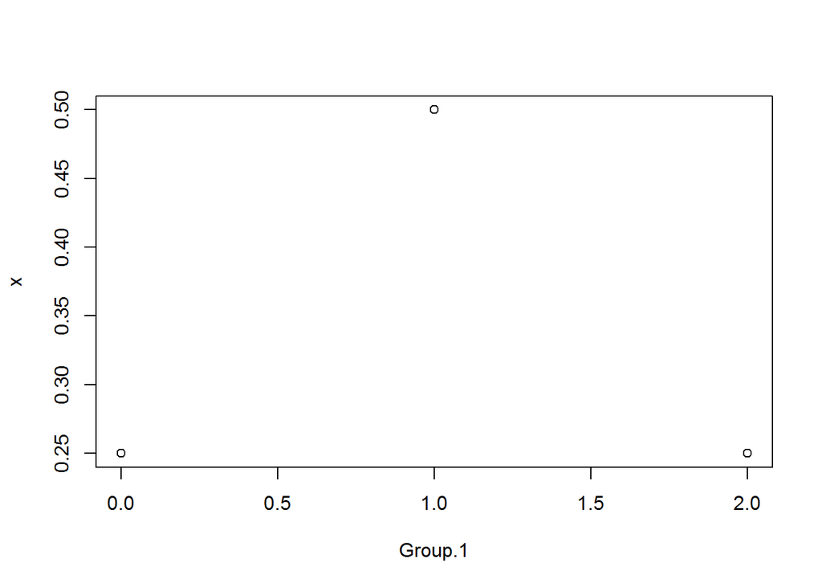

```r
plot(RV.nhead)
```

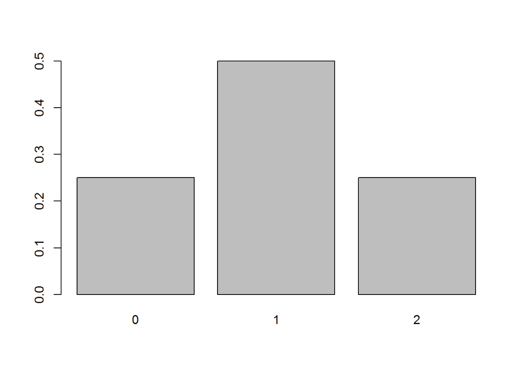

```r
barplot(RV.nhead[,2],names.arg=RV.nhead[,1])
```

#### 4. 평균과 분산(parameter)

- 이산확률변수
  - 평균
    $$E(X)=\sum_x x\cdot P(X=x)$$
  - 분산
    $$E(X-E(X))^2=\sum_x (x-E(X))^2\cdot P(X=x)=E(X^2)-(E(X))^2$$
- 연속확률변수
  - 평균
    $$E(X)=\int_x x\cdot f(x)dx$$
  - 분산
    $$E(X-E(X))^2=\int_x (x-E(X))^2 f(x)dx =E(X^2)-(E(X))^2$$
- parameter? : 모집단의 특성

```r
colnames(RV.nhead)=c("x","px")
Ex=sum(RV.nhead$x*RV.nhead$px)
Ex
```

```
## [1] 1
```

```r
Vx1=sum(((RV.nhead$x)^2)*RV.nhead$px)-Ex^2
Vx2=sum(((RV.nhead$x-Ex)^2)*RV.nhead$px)
Vx1
```

```
## [1] 0.5
```

```r
Vx2
```

```
## [1] 0.5
```

### Section 2: 분포함수

#### 베르누이 분포(Bernolli distribution)

- p의 확률로 성공하면 1, 실패하면 0이 되는 확률변수의 확률분포
- 확률

$$P(X)=p^x\cdot (1-p)^{1-x}\qquad x\in\{0,1\}$$

- 모수 = $p$
- 평균, 분산

$$E(X)=0\times p^0\cdot (1-p)^1 +1\times p^1\cdot (1-p)^0 = p$$
$$V(X)=E(X^2)-(E(X))^2=1^2\times p^1\cdot (1-p)^0-p^2 = p(1-p)$$

#### 이항분포(binomial distribution)

-성공확률이 p인 베르누이 시행을 n 번 반복하여 발생하는 성공 횟수의 확률분포 + n번의 독립적이고 동일한 베르누이 분포를 하는 확률변수의 합

- 확률

$$P(X)=\binom{n}{x} p^x\cdot (1-p)^{n-x}\qquad x\in\{0,1,2,,,,n\}$$

- 평균,분산

$$E(X)=\sum^{x=0}_{n} x \binom{n}{x} p^x\cdot (1-p)^{n-x} = np$$
$$V(X)=\sum^{x=0}_{n} x^2 \binom{n}{x} p^x\cdot (1-p)^{n-x} -(np)^2=np(1-p)$$

$$E(X)=E(\sum^{n}_{i=1}Z_i))=\sum^{n}_{i=1}E(Z_i)=np\qquad Z_i\sim B(1,p)$$
$$V(X)=E(\sum^{n}_{i=1}Z_i-E(\sum^{n}_{i=1}Z_i))^2=E(\sum^{n}_{i=1}Z_i-\sum^{n}_{i=1}E(Z_i))^2$$
$$=E(\sum^{n}_{i=1}Z_i-n\times E(Z_i))^2=E(\sum^{n}_{i=1}(Z_i-E(Z_i)))^2$$
$$=E(\sum^{n}_{i=1}(Z_i-E(Z_i))^2+\sum_{i\ne j}(Z_i-E(Z_i))(Z_j-E(Z_j)))$$
$$=E(\sum^{n}_{i=1}(Z_i-E(Z_i))^2)+\sum_{i\ne j}E(Z_i-E(Z_i))E(Z_j-E(Z_j)))$$
$$=E(\sum^{n}_{i=1}(Z_i-E(Z_i))^2)=\sum^{n}_{i=1}E(Z_i-E(Z_i))^2=np(1-p)$$

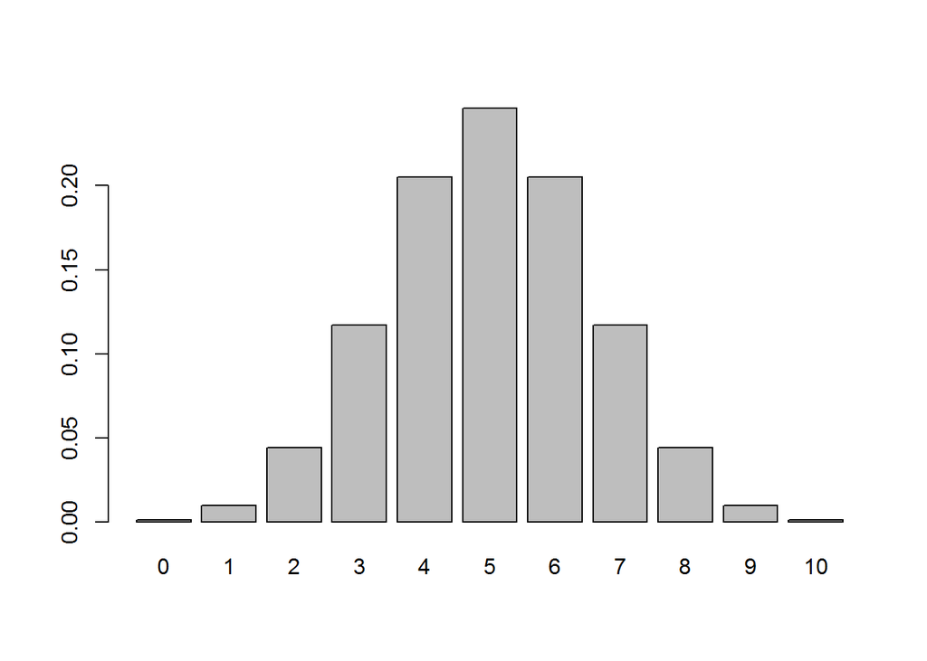

```r
n=10
p=0.5
x=(0:n)
px=dbinom(x,size=n,prob=p)
barplot(px,names.arg=x)
```

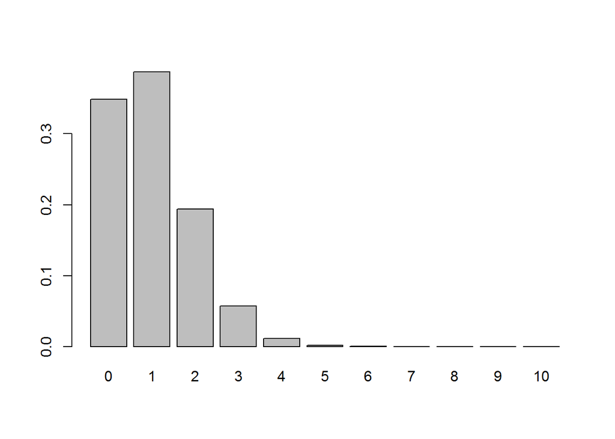

```r
p1=0.1
px1=dbinom(x,size=n,prob=p1)
barplot(px1,names.arg=x)
```

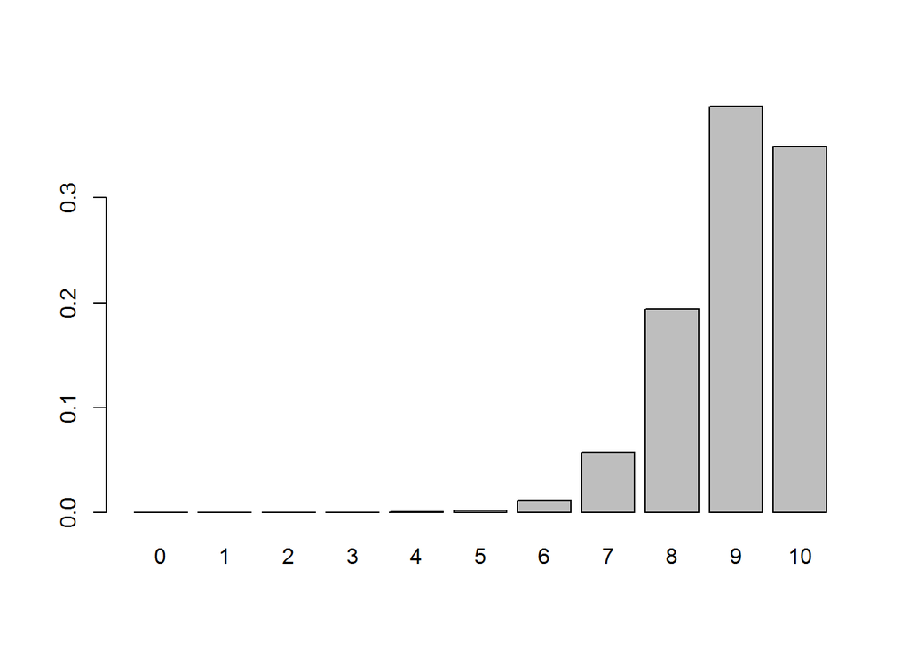

```r
p2=0.9
px2=dbinom(x,size=n,prob=p2)
barplot(px2,names.arg=x)
```

```r
n=6
p=1/3
x=0:n
# Probability
dbinom(2,size=n,prob=p)
```

```
## [1] 0.3292181
```

```r
dbinom(4,size=n,prob=p)
```

```
## [1] 0.08230453
```

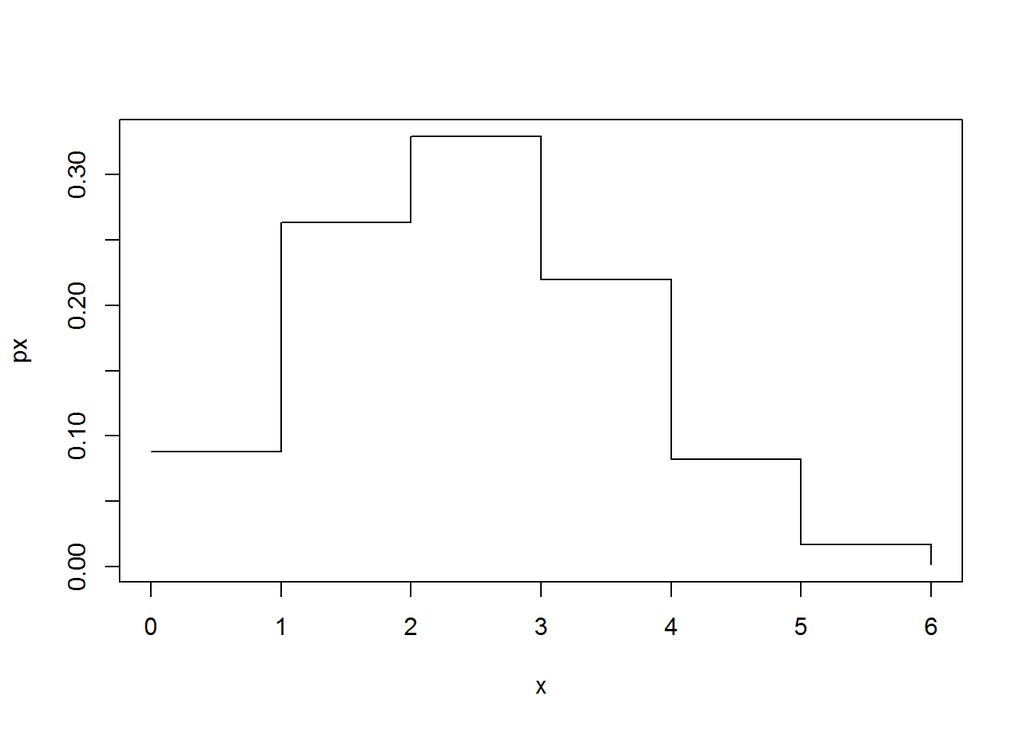

```r
px=dbinom(x,size=n,prob=p)
plot(x,px,type="s")
```

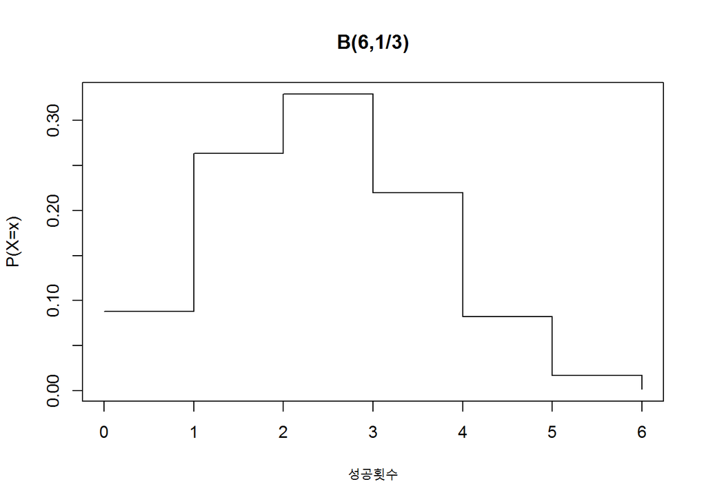

```r
plot(x,px,type="s",xlab="성공횟수",ylab="P(X=x)",main="B(6,1/3)")
```

```r
# distribution P(X\le x)
pbinom(2,size=n,prob=p) #P(x\le 2)
```

```
## [1] 0.6803841
```

```r
pbinom(4,size=n,prob=p) #P(x\le 4)
```

```
## [1] 0.9821674
```

```r
pbinom(4,size=n,prob=p)-pbinom(2,size=n,prob=p) # P((2,4]))
```

```
## [1] 0.3017833
```

```r
#Quantile from Random variable
qbinom(0.1,size=n,prob=p) #z . Pr(x \le z ) =0.1
```

```
## [1] 1
```

```r
qbinom(0.5,size=n,prob=p) #z . Pr(x \le z ) =0.5
```

```
## [1] 2
```

```r
#random number generation

rbinom(10,size=n,prob=p)
```

[output not shown]

```r
# mean

ex=sum(x*px)
ex2=sum(x^2*px)
vx=ex2-ex^2
ex
```

```
## [1] 2
```

```r
vx
```

```
## [1] 1.333333
```

#### 정규분포(normal distribution)

- 확률밀도함수, 분포함수

$$f(X)=\frac{1}{\sqrt{2\pi} \sigma}exp\left(-\frac{(x-\mu)^2}{\sigma^2}\right)$$
$$F(X)=\int^x_{-\infty}\frac{1}{\sqrt{2\pi} \sigma}exp\left(-\frac{(t-\mu)^2}{\sigma^2}\right)dt$$

- 모수 = $\mu,\sigma$
- 평균, 분산

$$E(x)=\int x\frac{1}{\sqrt{2\pi} \sigma}exp\left(-\frac{(x-\mu)^2}{\sigma^2}\right)dx =\mu$$
$$v(x)=\int (x-\mu)^2\frac{1}{\sqrt{2\pi} \sigma}exp\left(-\frac{(x-\mu)^2}{\sigma^2}\right)dx =\sigma^2$$

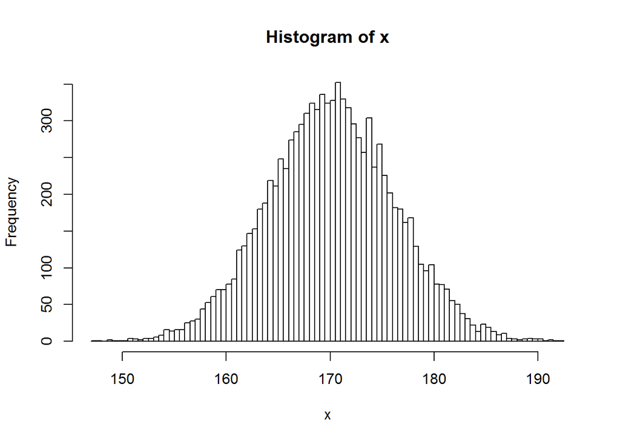

```r
x=rnorm(10000,mean=170,sd=6)
hist(x,breaks=100)
```

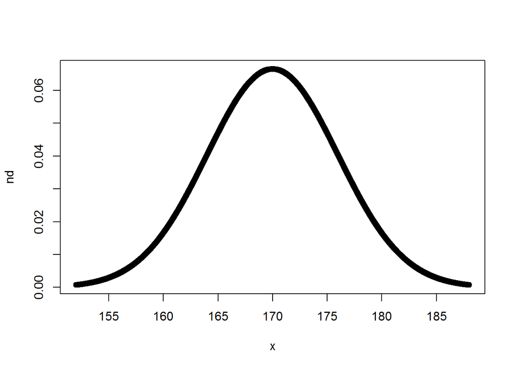

```r
options(digits=3)
mu=170
sigma=6
ll=170-3*sigma
ul=170+3*sigma
x=seq(ll,ul,by=0.01)
nd=dnorm(x,mean=mu,sd=sigma)
plot(x,nd)
```

```r
# distribution funciton
pnorm(mu,mean=mu,sd=sigma)
```

```
## [1] 0.5
```

```r
pnorm(159,mean=mu,sd=sigma) # P(x<159)
```

```
## [1] 0.0334
```

```r
pnorm(180,mean=mu,sd=sigma)-pnorm(160,mean=mu,sd=sigma) # P(160<x<180)
```

```
## [1] 0.904
```

```r
#quantile
qnorm(0.25,mean=mu,sd=sigma)
```

```
## [1] 166
```

```r
qnorm(0.5,mean=mu,sd=sigma)
```

```
## [1] 170
```

```r
qnorm(0.75,mean=mu,sd=sigma)
```

```
## [1] 174
```

```r
#random sample
options(digits=5)
set.seed(5)
smp=rnorm(400,mean=mu,sd=sigma)
mean(smp)
```

```
## [1] 170.02
```

```r
sd(smp)
```

```
## [1] 6.0054
```

```r
options(digits=4)
mu=0
sigma=1
p0.05=qnorm(0.05,mean=mu,sd=sigma)
p0.025=qnorm(0.025,mean=mu,sd=sigma)

pnorm(-1*p0.05)-pnorm(p0.05)
```

```
## [1] 0.9
```

```r
pnorm(-1.645)-pnorm(1.645)
```

```
## [1] -0.9
```

```r
pnorm(-1.96)-pnorm(1.96)
```

```
## [1] -0.95
```

### 3. 다음시간 준비: Loop

```r
v=c(1,4,5)
for (i in v){
  print(i)
}
```

```
## [1] 1
## [1] 4
## [1] 5
```

```r
r.n=rnorm(10)
SUM=0
for (i in 1:10){
  SUM=SUM+r.n[i]
}
print(SUM)
```

```
## [1] -3.549
```

```r
sum(r.n)
```

```
## [1] -3.549
```

```r
dan=2
for (i in 2:9){
  times=dan*i
  print(paste(dan, "X" ,i, "=",times))
}
```

```
## [1] "2 X 2 = 4"
## [1] "2 X 3 = 6"
## [1] "2 X 4 = 8"
## [1] "2 X 5 = 10"
## [1] "2 X 6 = 12"
## [1] "2 X 7 = 14"
## [1] "2 X 8 = 16"
## [1] "2 X 9 = 18"
```

```r
m=matrix(1:12,ncol=3)
for (i in 1:nrow(m)){
  for (j in 1:ncol(m)){
    cat(i, "행", j, "열=", m[i,j],"\n")
}
}
```

```
## 1 행 1 열= 1
## 1 행 2 열= 5
## 1 행 3 열= 9
## 2 행 1 열= 2
## 2 행 2 열= 6
## 2 행 3 열= 10
## 3 행 1 열= 3
## 3 행 2 열= 7
## 3 행 3 열= 11
## 4 행 1 열= 4
## 4 행 2 열= 8
## 4 행 3 열= 12
```

```r
times=1
i=0
while (times<(2000/2)){
  times=times*2
  i=i+1
    print(paste(2, "^" ,i, "=",times))
}
```

```
## [1] "2 ^ 1 = 2"
## [1] "2 ^ 2 = 4"
## [1] "2 ^ 3 = 8"
## [1] "2 ^ 4 = 16"
## [1] "2 ^ 5 = 32"
## [1] "2 ^ 6 = 64"
## [1] "2 ^ 7 = 128"
## [1] "2 ^ 8 = 256"
## [1] "2 ^ 9 = 512"
## [1] "2 ^ 10 = 1024"
```

```r
S=1234
r=0.01
i=0
while(S<20000){
  print("i= ")
  print(i)
  print("S= ")
  print(S)

  i=i+1
  S=S+S/{(1+r)^i}

}
```

```
## [1] "i= "
## [1] 0
## [1] "S= "
## [1] 1234
## [1] "i= "
## [1] 1
## [1] "S= "
## [1] 2456
## [1] "i= "
## [1] 2
## [1] "S= "
## [1] 4863
## [1] "i= "
## [1] 3
## [1] "S= "
## [1] 9583
## [1] "i= "
## [1] 4
## [1] "S= "
## [1] 18793
```